# Store closings

Following along at https://rud.is/b/2017/03/19/exploring-2017-retail-store-closings-with-r/ and http://rpubs.com/hrbrmstr/stores_2017 and

```r
library(httr)
library(rvest)
library(knitr)
library(kableExtra)
library(ggalt)
library(statebins)
library(hrbrthemes)
library(purrr)
library(readr)
library(dplyr)
library(epidata)
```

```r
update_geom_font_defaults(font_rc_light, size = 2.75)
```

The Boston Globe has a nice list of store closings.

```r
closings <- list(
  kmart = "https://www.bostonglobe.com/metro/2017/01/05/the-full-list-kmart-stores-closing-around/4kJ0YVofUWHy5QJXuPBAuM/story.html",
  sears = "https://www.bostonglobe.com/metro/2017/01/05/the-full-list-sears-stores-closing-around/yHaP6nV2C4gYw7KLhuWuFN/story.html",
  macys = "https://www.bostonglobe.com/metro/2017/01/05/the-full-list-macy-stores-closing-around/6TY8a3vy7yneKV1nYcwY7K/story.html",
    jcp = "https://www.bostonglobe.com/business/2017/03/17/the-full-list-penney-stores-closing-around/vhoHjI3k75k2pSuQt2mZpO/story.html"
)
```

We’ll store to a file only if it isn’t there.

```r
if (file.exists(saved_pgs)) {
  pgs <- readr::read_rds(saved_pgs)
} else {
  pgs <- purrr::map(closings, httr::GET)
  readr::write_rds(pgs, saved_pgs)  # from readr - writes a single object without compression (space is cheap)
}
```

What did we get?

```r
purrr::map(pgs, httr::content)
```

```
$kmart
{xml_document}
<html>
[1] <head>\n<meta http-equiv="Content-Type" content="text/html; charset=UTF-8">\n<meta charset="UTF-8">\n<script type="text/javascript">\n\tvar meth ...
[2] <body itemscope itemtype="http://schema.org/WebPage" class="type-internal type-article section-metro metro type-metro logged-out">\n\n<div id="c ...

$sears
{xml_document}
<html>
[1] <head>\n<meta http-equiv="Content-Type" content="text/html; charset=UTF-8">\n<meta charset="UTF-8">\n<script type="text/javascript">\n\tvar meth ...
[2] <body itemscope itemtype="http://schema.org/WebPage" class="type-internal type-article section-metro metro type-metro logged-out">\n\n<div id="c ...

$macys
{xml_document}
<html>
[1] <head>\n<meta http-equiv="Content-Type" content="text/html; charset=UTF-8">\n<meta charset="UTF-8">\n<script type="text/javascript">\n\tvar meth ...
[2] <body itemscope itemtype="http://schema.org/WebPage" class="type-internal type-article section-metro metro type-metro logged-out">\n\n<div id="c ...

$jcp
{xml_document}
<html>
[1] <head>\n<meta http-equiv="Content-Type" content="text/html; charset=UTF-8">\n<meta charset="UTF-8">\n<script type="text/javascript">\n\tvar meth ...
[2] <body itemscope itemtype="http://schema.org/WebPage" class="type-internal type-article section-business &amp; tech business &amp; tech type-busi ...
```

```r
purrr::map(pgs, httr::content) %>%
  purrr::map(rvest::html_table) %>%
  purrr::walk(~dplyr::glimpse(.[[1]]))
```

```
Observations: 108
Variables: 3
$ X1 <chr> "300 Highway 78 E", "2003 US Hwy 280 Bypass", "3600 Wilson Road", "25 West Polk Street", "333 Sierra Street", "3001 Iowa Avenue", "363 ...
$ X2 <chr> "Jasper", "Phenix City", "Bakersfield", "Coalinga", "Kingsburg", "Riverside", "Denver", "Grand Junction", "Cromwell", "Sarasota", "Crys...
$ X3 <chr> "AL", "AL", "CA", "CA", "CA", "CA", "CO", "CO", "CT", "FL", "FL", "FL", "FL", "FL", "FL", "FL", "FL", "FL", "GA", "GA", "GA", "GA", "HI...
Observations: 42
Variables: 4
$ X1 <chr> "301 Cox Creek Pkwy", "1901 S Caraway Road", "90 Elm St; Enfield Sq", "301 Eagle Ridge Dr", "Albany Mall", "5555 Whittlesey Blvd", "123...
$ X2 <chr> "Florence", "Jonesboro", "Enfield", "Lake Wales", "Albany", "Columbus", "Kokomo", "Salina", "Paducah", "Baton Rouge / Cortana", "Gretna...
$ X3 <chr> "AL", "AR", "CT", "FL", "GA", "GA", "IN", "KS", "KY", "LA", "LA", "MA", "ME", "MI", "MN", "MN", "MO", "MO", "ND", "NM", "NY", "NY", "NY...
$ X4 <chr> "Y", "N", "N", "Y", "Y", "N", "N", "N", "Y", "Y", "Y", "Y", "Y", "Y", "Y", "Y", "Y", "N", "Y", "N", "Y", "Y", "Y", "N", "Y", "Y", "Y", ...
Observations: 68
Variables: 6
$ X1 <chr> "Mission Valley Apparel", "Paseo Nuevo", "*Laurel Plaza", "Simi Valley Town Center (men’s/home/kids)", "Lakeland Square", "Oviedo Marke...
$ X2 <chr> "San Diego", "Santa Barbara", "North Hollywood", "Simi Valley", "Lakeland", "Oviedo", "Sarasota", "Tampa", "West Palm Beach", "Athens",...
$ X3 <chr> "CA", "CA", "CA", "CA", "FL", "FL", "FL", "FL", "FL", "GA", "HI", "ID", "IL", "IL", "IL", "KY", "KY", "LA", "MA", "MA", "ME", "MI", "MI...
$ X4 <int> 385000, 141000, 475000, 190000, 101000, 195000, 143000, 140000, 108000, 121000, 2000, 104000, 180000, 149000, 154000, 157000, 124000, 1...
$ X5 <int> 1961, 1990, 1995, 2006, 1995, 2000, 1977, 1974, 2000, 1981, 1986, 2009, 1978, 1981, 1999, 1979, 1980, 2008, 2003, 1992, 1998, 1983, 195...
$ X6 <int> 140, 77, 105, 105, 68, 83, 86, 73, 72, 69, 9, 57, 54, 87, 55, 52, 63, 101, 79, 82, 65, 51, 121, 57, 106, 280, 72, 69, 53, 107, 77, 72, ...
Observations: 138
Variables: 3
$ Mall/Shopping Center <chr> "Auburn Mall", "Tannehill Promenade", "Gadsden Mall", "Jasper Mall", "Military Plaza", "Chickasaw Plaza", "Riverview ...
$ City                 <chr> "Auburn", "Bessemer", "Gadsden", "Jasper", "Benton", "Blytheville", "Bullhead City", "Bishop", "Lodi", "Orange", "Ric...
$ State                <chr> "AL", "AL", "AL", "AL", "AR", "AR", "AZ", "CA", "CA", "CA", "CA", "CO", "CO", "CO", "CO", "CT", "FL", "FL", "GA", "GA...
```

Normalize these lists.

```r
map(pgs, content) %>%
  map(html_table) %>%
  map(~.[[1]]) %>%
  map_df(select, abb=3, .id = "store") -> closings
```

Just get count of stores…

```r
count(closings, abb) %>%
  left_join(data_frame(name = state.name, abb = state.abb)) %>%
  left_join(usmap::statepop, by = c("abb"="abbr")) %>%   # must install usmap package
  mutate(per_capita = (n/pop_2015) * 1000000) %>%
  select(name, n, per_capita) -> closings_by_state
```

```r
closings_by_state
```

| name | n | per_capita |
| --- | --- | --- |
| Alabama | 7 | 1.4406319 |
| Arkansas | 3 | 1.0073185 |
| Arizona | 1 | 0.1464544 |
| California | 12 | 0.3065540 |
| Colorado | 6 | 1.0995911 |
| Connecticut | 3 | 0.8354484 |
| Florida | 17 | 0.8386252 |
| Georgia | 12 | 1.1747591 |
| Hawaii | 2 | 1.3970354 |
| Iowa | 7 | 2.2407895 |

[output cut: 36 more lines]

## 2017 Retail Stores (Combined) Closing

Sears, JC Penny, K-Mart and Macy’s are closing stores

### Sorted by closigs per-capita (1MM)

```
`show_guide` has been deprecated. Please use `show.legend` instead.
```

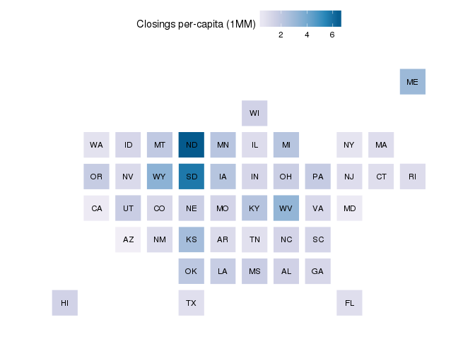

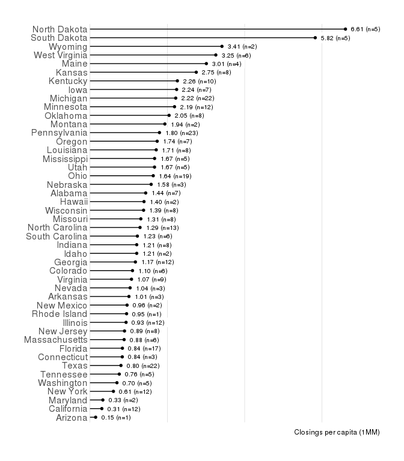

Retail Stores Closing (sorted by per-capita)

| State | Total Stores Closing | Per Capita (1MM) |
| --- | --- | --- |
| North Dakota | 5 | 6.6056568 |
| South Dakota | 5 | 5.8243221 |
| Wyoming | 2 | 3.4123462 |
| West Virginia | 6 | 3.2535703 |
| Maine | 4 | 3.0090392 |
| Kansas | 8 | 2.7475915 |
| Kentucky | 10 | 2.2598400 |
| Iowa | 7 | 2.2407895 |
| Michigan | 22 | 2.2171662 |
| Minnesota | 12 | 2.1859540 |
| Oklahoma | 8 | 2.0453359 |
| Montana | 2 | 1.9362040 |
| Pennsylvania | 23 | 1.7965237 |
| Oregon | 7 | 1.7374137 |
| Louisiana | 8 | 1.7127966 |
| Mississippi | 5 | 1.6709370 |
| Utah | 5 | 1.6689370 |
| Ohio | 19 | 1.6360379 |
| Nebraska | 3 | 1.5821199 |
| Alabama | 7 | 1.4406319 |
| Hawaii | 2 | 1.3970354 |
| Wisconsin | 8 | 1.3861606 |
| Missouri | 8 | 1.3149953 |
| North Carolina | 13 | 1.2944595 |
| South Carolina | 6 | 1.2254537 |
| Indiana | 8 | 1.2085176 |
| Idaho | 2 | 1.2085103 |
| Georgia | 12 | 1.1747591 |
| Colorado | 6 | 1.0995911 |
| Virginia | 9 | 1.0736022 |
| Nevada | 3 | 1.0377589 |
| Arkansas | 3 | 1.0073185 |
| New Mexico | 2 | 0.9591825 |
| Rhode Island | 1 | 0.9467025 |
| Illinois | 12 | 0.9331263 |
| New Jersey | 8 | 0.8930552 |
| Massachusetts | 6 | 0.8830773 |
| Florida | 17 | 0.8386252 |
| Connecticut | 3 | 0.8354484 |
| Texas | 22 | 0.8008995 |
| Tennessee | 5 | 0.7575414 |
| Washington | 5 | 0.6973159 |
| New York | 12 | 0.6061895 |
| Maryland | 2 | 0.3329781 |
| California | 12 | 0.3065540 |
| Arizona | 1 | 0.1464544 |

### Sorted by total stores closing

```
`show_guide` has been deprecated. Please use `show.legend` instead.
```

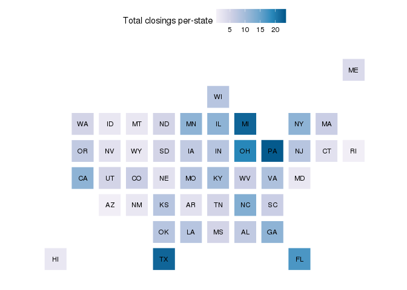

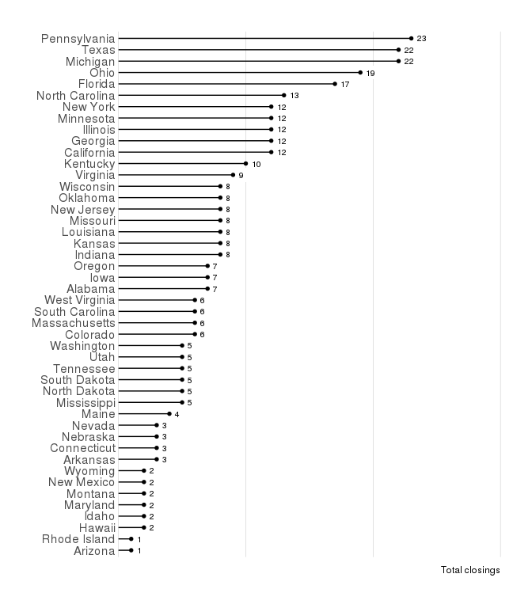

Retail Stores Closing (sorted by total stores)

| State | Total Stores Closing | Per Capita (1MM) |
| --- | --- | --- |
| Pennsylvania | 23 | 1.7965237 |
| Michigan | 22 | 2.2171662 |
| Texas | 22 | 0.8008995 |
| Ohio | 19 | 1.6360379 |
| Florida | 17 | 0.8386252 |
| North Carolina | 13 | 1.2944595 |
| California | 12 | 0.3065540 |
| Georgia | 12 | 1.1747591 |
| Illinois | 12 | 0.9331263 |
| Minnesota | 12 | 2.1859540 |
| New York | 12 | 0.6061895 |
| Kentucky | 10 | 2.2598400 |
| Virginia | 9 | 1.0736022 |
| Indiana | 8 | 1.2085176 |
| Kansas | 8 | 2.7475915 |
| Louisiana | 8 | 1.7127966 |
| Missouri | 8 | 1.3149953 |
| New Jersey | 8 | 0.8930552 |
| Oklahoma | 8 | 2.0453359 |
| Wisconsin | 8 | 1.3861606 |
| Alabama | 7 | 1.4406319 |
| Iowa | 7 | 2.2407895 |
| Oregon | 7 | 1.7374137 |
| Colorado | 6 | 1.0995911 |
| Massachusetts | 6 | 0.8830773 |
| South Carolina | 6 | 1.2254537 |
| West Virginia | 6 | 3.2535703 |
| Mississippi | 5 | 1.6709370 |
| North Dakota | 5 | 6.6056568 |
| South Dakota | 5 | 5.8243221 |
| Tennessee | 5 | 0.7575414 |
| Utah | 5 | 1.6689370 |
| Washington | 5 | 0.6973159 |
| Maine | 4 | 3.0090392 |
| Arkansas | 3 | 1.0073185 |
| Connecticut | 3 | 0.8354484 |
| Nebraska | 3 | 1.5821199 |
| Nevada | 3 | 1.0377589 |
| Hawaii | 2 | 1.3970354 |
| Idaho | 2 | 1.2085103 |
| Maryland | 2 | 0.3329781 |
| Montana | 2 | 1.9362040 |
| New Mexico | 2 | 0.9591825 |
| Wyoming | 2 | 3.4123462 |
| Arizona | 1 | 0.1464544 |
| Rhode Island | 1 | 0.9467025 |

### Sorted by state name

Retail Stores Closing (sorted by state name)

| State | Total Stores Closing | Per Capita (1MM) |
| --- | --- | --- |
| Alabama | 7 | 1.4406319 |
| Arizona | 1 | 0.1464544 |
| Arkansas | 3 | 1.0073185 |
| California | 12 | 0.3065540 |
| Colorado | 6 | 1.0995911 |
| Connecticut | 3 | 0.8354484 |
| Florida | 17 | 0.8386252 |
| Georgia | 12 | 1.1747591 |
| Hawaii | 2 | 1.3970354 |
| Idaho | 2 | 1.2085103 |
| Illinois | 12 | 0.9331263 |
| Indiana | 8 | 1.2085176 |
| Iowa | 7 | 2.2407895 |
| Kansas | 8 | 2.7475915 |
| Kentucky | 10 | 2.2598400 |
| Louisiana | 8 | 1.7127966 |
| Maine | 4 | 3.0090392 |
| Maryland | 2 | 0.3329781 |
| Massachusetts | 6 | 0.8830773 |
| Michigan | 22 | 2.2171662 |
| Minnesota | 12 | 2.1859540 |
| Mississippi | 5 | 1.6709370 |
| Missouri | 8 | 1.3149953 |
| Montana | 2 | 1.9362040 |
| Nebraska | 3 | 1.5821199 |
| Nevada | 3 | 1.0377589 |
| New Jersey | 8 | 0.8930552 |
| New Mexico | 2 | 0.9591825 |
| New York | 12 | 0.6061895 |
| North Carolina | 13 | 1.2944595 |
| North Dakota | 5 | 6.6056568 |
| Ohio | 19 | 1.6360379 |
| Oklahoma | 8 | 2.0453359 |
| Oregon | 7 | 1.7374137 |
| Pennsylvania | 23 | 1.7965237 |
| Rhode Island | 1 | 0.9467025 |
| South Carolina | 6 | 1.2254537 |
| South Dakota | 5 | 5.8243221 |
| Tennessee | 5 | 0.7575414 |
| Texas | 22 | 0.8008995 |
| Utah | 5 | 1.6689370 |
| Virginia | 9 | 1.0736022 |
| Washington | 5 | 0.6973159 |
| West Virginia | 6 | 3.2535703 |
| Wisconsin | 8 | 1.3861606 |
| Wyoming | 2 | 3.4123462 |

## Compared to unemployment

I’d have used the [`epidata`](https://cran.rstudio.com/web/packages/epidata/) to get the current state unemployment data but it’s not current, so we can either use a package to get data from the Bureau of Labor Statistics or just scrape it. We’ll use the U-6 rate since that is an expanded definition including *“total unemployed, plus all marginally attached workers, plus total employed part time for economic reasons, as a percent of the civilian labor force plus all marginally attached workers”* and is likely to more representative for the populations working at retail chains.

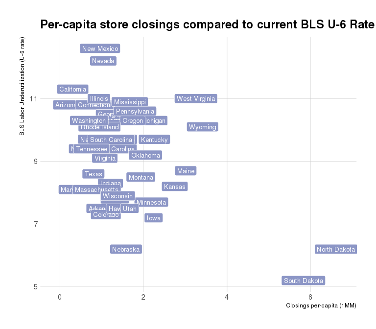

```r
pg <- read_html("https://www.bls.gov/lau/stalt16q4.htm")
html_nodes(pg, "table#alternmeas16\\:IV") %>%
  html_table(header = TRUE, fill = TRUE) %>%
  .[[1]] %>%
  docxtractr::assign_colnames(1) %>%
  rename(name=State) %>%
  as_data_frame() %>%
  slice(2:52) %>%
  type_convert() %>%
  left_join(closings_by_state, by="name") %>%
  filter(!is.na(n)) -> with_unemp
ggplot(with_unemp, aes(per_capita, `U-6`)) +
  geom_label(aes(label=name), fill="#8c96c6", color="white", size=3.5, family=font_rc) +
  scale_x_continuous(limits=c(-0.125, 6.75)) +
  labs(x="Closings per-capita (1MM)",
       y="BLS Labor Underutilization (U-6 rate)",
       title="Per-capita store closings compared to current BLS U-6 Rate") +
  theme_ipsum_rc(grid="XY")
```

If I were a reporter, I think I’d be digging a bit deeper on the impact of these (and the half-dozen or so other) retailers closing locations in New Mexico, Nevada, West Virginia, Wyoming, (mebbe Maine, though I’m super-b ased :-), North Dakota & South Dakota.